# Diwali sales analysis

```python
import numpy as np
import pandas as pd
import matplotlib.pyplot as plt
%matplotlib inline
import seaborn as sns
```

```python
df=pd.read_csv(r'E:\Darshan\Diwali Sales Data.csv',encoding='unicode_escape')
```

```python
df.shape
```

```
(11251, 15)
```

```python
df.head(1)
```

|  | User_ID | Cust_name | Product_ID | Gender | Age Group | Age | Marital_Status | State | Zone | Occupation | Product_Category | Orders | Amount | Status | unnamed1 |
| --- | --- | --- | --- | --- | --- | --- | --- | --- | --- | --- | --- | --- | --- | --- | --- |
| 0 | 1002903 | Sanskriti | P00125942 | F | 26-35 | 28 | 0 | Maharashtra | Western | Healthcare | Auto | 1 | 23952.0 | NaN | NaN |

```python
df.tail(5)
```

|  | User_ID | Cust_name | Product_ID | Gender | Age Group | Age | Marital_Status | State | Zone | Occupation | Product_Category | Orders | Amount | Status | unnamed1 |
| --- | --- | --- | --- | --- | --- | --- | --- | --- | --- | --- | --- | --- | --- | --- | --- |
| 11246 | 1000695 | Manning | P00296942 | M | 18-25 | 19 | 1 | Maharashtra | Western | Chemical | Office | 4 | 370.0 | NaN | NaN |
| 11247 | 1004089 | Reichenbach | P00171342 | M | 26-35 | 33 | 0 | Haryana | Northern | Healthcare | Veterinary | 3 | 367.0 | NaN | NaN |
| 11248 | 1001209 | Oshin | P00201342 | F | 36-45 | 40 | 0 | Madhya Pradesh | Central | Textile | Office | 4 | 213.0 | NaN | NaN |
| 11249 | 1004023 | Noonan | P00059442 | M | 36-45 | 37 | 0 | Karnataka | Southern | Agriculture | Office | 3 | 206.0 | NaN | NaN |
| 11250 | 1002744 | Brumley | P00281742 | F | 18-25 | 19 | 0 | Maharashtra | Western | Healthcare | Office | 3 | 188.0 | NaN | NaN |

```python
df.info()
```

```
<class 'pandas.DataFrame'>
RangeIndex: 11251 entries, 0 to 11250
Data columns (total 15 columns):
 #   Column            Non-Null Count  Dtype
---  ------            --------------  -----
 0   User_ID           11251 non-null  int64
 1   Cust_name         11251 non-null  str
 2   Product_ID        11251 non-null  str
 3   Gender            11251 non-null  str
 4   Age Group         11251 non-null  str
 5   Age               11251 non-null  int64
 6   Marital_Status    11251 non-null  int64
 7   State             11251 non-null  str
 8   Zone              11251 non-null  str
 9   Occupation        11251 non-null  str
 10  Product_Category  11251 non-null  str
 11  Orders            11251 non-null  int64
 12  Amount            11239 non-null  float64
 13  Status            0 non-null      float64
 14  unnamed1          0 non-null      float64
dtypes: float64(3), int64(4), str(8)
memory usage: 1.3 MB
```

```python
print(df.columns)
```

```
Index(['User_ID', 'Cust_name', 'Product_ID', 'Gender', 'Age Group', 'Age',
       'Marital_Status', 'State', 'Zone', 'Occupation', 'Product_Category',
       'Orders', 'Amount', 'Status', 'unnamed1'],
      dtype='str')
```

```python
df.shape
```

```
(11251, 15)
```

```python
df.drop(['Status','unnamed1'],axis=1,inplace=True)
```

```python
df.columns
```

```
Index(['User_ID', 'Cust_name', 'Product_ID', 'Gender', 'Age Group', 'Age',
       'Marital_Status', 'State', 'Zone', 'Occupation', 'Product_Category',
       'Orders', 'Amount'],
      dtype='str')
```

```python
pd.isnull(df).sum()
```

```
User_ID              0
Cust_name            0
Product_ID           0
Gender               0
Age Group            0
Age                  0
Marital_Status       0
State                0
Zone                 0
Occupation           0
Product_Category     0
Orders               0
Amount              12
dtype: int64
```

```python
df.dropna(inplace=True)
```

```python
pd.isnull(df).sum()
```

```
User_ID             0
Cust_name           0
Product_ID          0
Gender              0
Age Group           0
Age                 0
Marital_Status      0
State               0
Zone                0
Occupation          0
Product_Category    0
Orders              0
Amount              0
dtype: int64
```

```python
df.shape
```

```
(11239, 13)
```

```python
print(df.shape)
print(df.ndim)
print(df.size)
```

```
(11239, 13)
2
146107
```

```python
#converting floating value there in amounts to integer value
df['Amount']=df['Amount'].astype('int')
```

```python
df["Amount"].dtype
```

```
dtype('int64')
```

```python
df=df.rename(columns={"Marital_Status":"Married?"})
print(df.columns)
```

```
Index(['User_ID', 'Cust_name', 'Product_ID', 'Gender', 'Age Group', 'Age',
       'Married?', 'State', 'Zone', 'Occupation', 'Product_Category', 'Orders',
       'Amount'],
      dtype='str')
```

```python
df.info()
```

```
<class 'pandas.DataFrame'>
Index: 11239 entries, 0 to 11250
Data columns (total 13 columns):
 #   Column            Non-Null Count  Dtype
---  ------            --------------  -----
 0   User_ID           11239 non-null  int64
 1   Cust_name         11239 non-null  str
 2   Product_ID        11239 non-null  str
 3   Gender            11239 non-null  str
 4   Age Group         11239 non-null  str
 5   Age               11239 non-null  int64
 6   Married?          11239 non-null  int64
 7   State             11239 non-null  str
 8   Zone              11239 non-null  str
 9   Occupation        11239 non-null  str
 10  Product_Category  11239 non-null  str
 11  Orders            11239 non-null  int64
 12  Amount            11239 non-null  int64
dtypes: int64(5), str(8)
memory usage: 1.2 MB
```

```python
df.describe(include="all")
```

|  | User_ID | Cust_name | Product_ID | Gender | Age Group | Age | Married? | State | Zone | Occupation | Product_Category | Orders | Amount |
| --- | --- | --- | --- | --- | --- | --- | --- | --- | --- | --- | --- | --- | --- |
| count | 1.123900e+04 | 11239 | 11239 | 11239 | 11239 | 11239.000000 | 11239.000000 | 11239 | 11239 | 11239 | 11239 | 11239.000000 | 11239.000000 |
| unique | NaN | 1250 | 2350 | 2 | 7 | NaN | NaN | 16 | 5 | 15 | 18 | NaN | NaN |
| top | NaN | Vishakha | P00265242 | F | 26-35 | NaN | NaN | Uttar Pradesh | Central | IT Sector | Clothing & Apparel | NaN | NaN |
| freq | NaN | 42 | 53 | 7832 | 4541 | NaN | NaN | 1944 | 4289 | 1583 | 2655 | NaN | NaN |
| mean | 1.003004e+06 | NaN | NaN | NaN | NaN | 35.410357 | 0.420055 | NaN | NaN | NaN | NaN | 2.489634 | 9453.610553 |
| std | 1.716039e+03 | NaN | NaN | NaN | NaN | 12.753866 | 0.493589 | NaN | NaN | NaN | NaN | 1.114967 | 5222.355168 |
| min | 1.000001e+06 | NaN | NaN | NaN | NaN | 12.000000 | 0.000000 | NaN | NaN | NaN | NaN | 1.000000 | 188.000000 |
| 25% | 1.001492e+06 | NaN | NaN | NaN | NaN | 27.000000 | 0.000000 | NaN | NaN | NaN | NaN | 2.000000 | 5443.000000 |
| 50% | 1.003064e+06 | NaN | NaN | NaN | NaN | 33.000000 | 0.000000 | NaN | NaN | NaN | NaN | 2.000000 | 8109.000000 |
| 75% | 1.004426e+06 | NaN | NaN | NaN | NaN | 43.000000 | 1.000000 | NaN | NaN | NaN | NaN | 3.000000 | 12675.000000 |
| max | 1.006040e+06 | NaN | NaN | NaN | NaN | 92.000000 | 1.000000 | NaN | NaN | NaN | NaN | 4.000000 | 23952.000000 |

```python
df['Gender'].value_counts()
```

```
Gender
F    7832
M    3407
Name: count, dtype: int64
```

```python
#
df.select_dtypes(include=['int','float']).columns
```

```
Index(['User_ID', 'Age', 'Married?', 'Orders', 'Amount'], dtype='str')
```

```python
df.describe()
```

|  | User_ID | Age | Married? | Orders | Amount |
| --- | --- | --- | --- | --- | --- |
| count | 1.123900e+04 | 11239.000000 | 11239.000000 | 11239.000000 | 11239.000000 |
| mean | 1.003004e+06 | 35.410357 | 0.420055 | 2.489634 | 9453.610553 |
| std | 1.716039e+03 | 12.753866 | 0.493589 | 1.114967 | 5222.355168 |
| min | 1.000001e+06 | 12.000000 | 0.000000 | 1.000000 | 188.000000 |
| 25% | 1.001492e+06 | 27.000000 | 0.000000 | 2.000000 | 5443.000000 |
| 50% | 1.003064e+06 | 33.000000 | 0.000000 | 2.000000 | 8109.000000 |
| 75% | 1.004426e+06 | 43.000000 | 1.000000 | 3.000000 | 12675.000000 |
| max | 1.006040e+06 | 92.000000 | 1.000000 | 4.000000 | 23952.000000 |

# **EXPLOARATORY DATA ANALYSIS**

# Gender

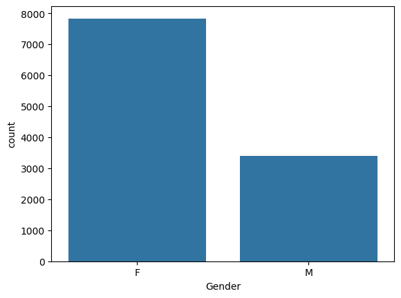

```python
ax=sns.countplot(x="Gender",data=df)
```

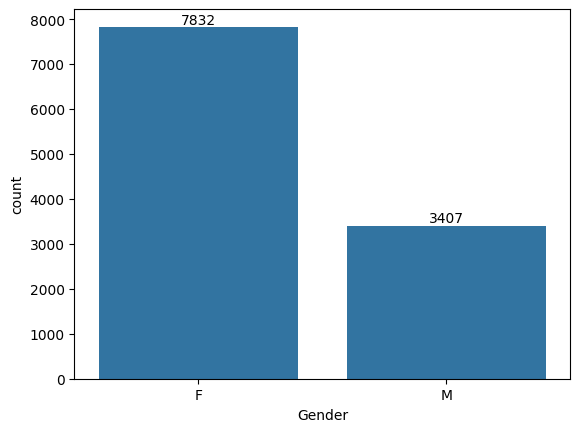

```python
ax=sns.countplot(data=df,x="Gender")
for bar in ax.containers:
    ax.bar_label(bar)
```

# Gender vs Amount

```python
df.groupby(["Gender"],as_index=False)["Amount"].sum().sort_values(by="Amount",ascending=False)
```

|  | Gender | Amount |
| --- | --- | --- |
| 0 | F | 74335853 |
| 1 | M | 31913276 |

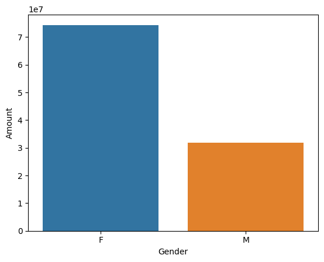

```python
sales_Gen=df.groupby(["Gender"],as_index=False)["Amount"].sum().sort_values(by="Amount",ascending=False)
#color=['yellow' if g=="M" else "black" for g in sales_Gen["Gender"]]
sns.barplot(x="Gender",y="Amount",hue="Gender",data=sales_Gen)
plt.show()
```

from above graphh we can see that most of the buyers are female and power of buying from female is more than male

```python
df.columns
```

```
Index(['User_ID', 'Cust_name', 'Product_ID', 'Gender', 'Age Group', 'Age',
       'Married?', 'State', 'Zone', 'Occupation', 'Product_Category', 'Orders',
       'Amount'],
      dtype='str')
```

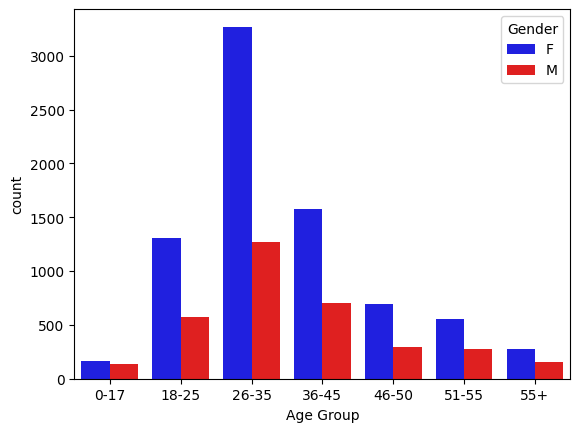

```python
order=sorted(df["Age Group"].unique())
sns.countplot(x="Age Group",hue="Gender",data=df,order=order,palette={"M":"red","F":"blue"})
plt.show()
```

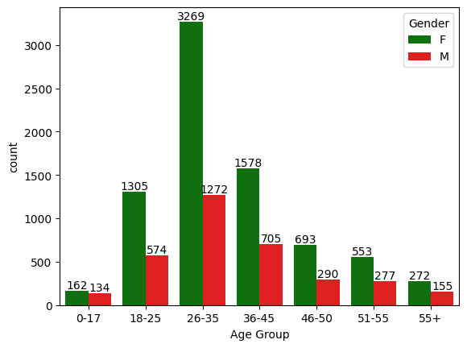

```python
asi=sns.countplot(x="Age Group",data=df,hue="Gender",palette={"M":"red","F":"green"},order=sorted(df["Age Group"].unique()))
for bar in asi.containers:
    asi.bar_label(bar)
```

```python
df.groupby(["Age Group"],as_index=False)["Amount"].sum().sort_values(by="Amount",ascending=False)
```

|  | Age Group | Amount |
| --- | --- | --- |
| 2 | 26-35 | 42613442 |
| 3 | 36-45 | 22144994 |
| 1 | 18-25 | 17240732 |
| 4 | 46-50 | 9207844 |
| 5 | 51-55 | 8261477 |
| 6 | 55+ | 4080987 |
| 0 | 0-17 | 2699653 |

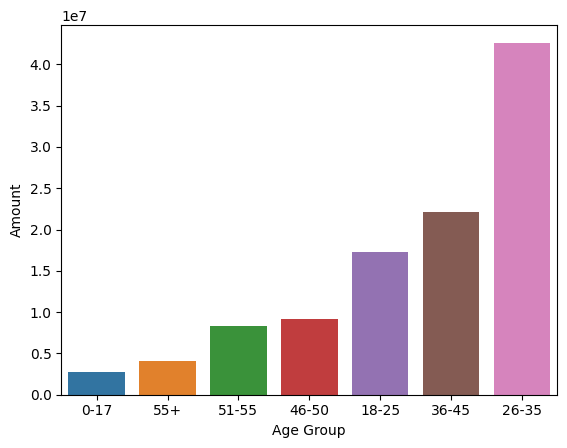

```python
sales_Age=df.groupby(["Age Group"],as_index=False)["Amount"].sum().sort_values(by="Amount",ascending=True)
sns.barplot(x="Age Group",y="Amount",data=sales_Age,hue="Age Group")
plt.show()
```

we can see that most of the buyers from age group 26 to 35

# State

```python
    df["State"]
```

```
0           Maharashtra
1        Andhra Pradesh
2         Uttar Pradesh
3             Karnataka
4               Gujarat
              ...
11246       Maharashtra
11247           Haryana
11248    Madhya Pradesh
11249         Karnataka
11250       Maharashtra
Name: State, Length: 11239, dtype: str
```

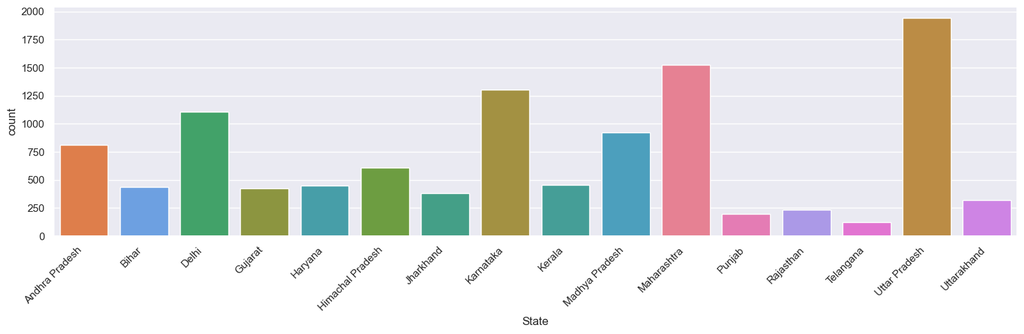

```python
order=sorted(df["State"].unique())
plt.figure(figsize=(15,5))
sns.countplot(x="State",data=df,order=order,hue="State")
plt.xticks(rotation=45,ha="right")
plt.tight_layout()
plt.show()
```

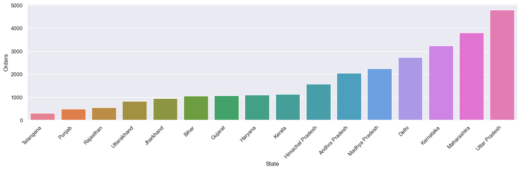

```python
sales_state=df.groupby(["State"],as_index=False)["Orders"].sum().sort_values(by="Orders",ascending=True)
plt.figure(figsize=(15,5))
sns.barplot(x="State",y="Orders",data=sales_state,hue="State")
plt.xticks(rotation=45,ha="right")
plt.tight_layout()
plt.show()
```

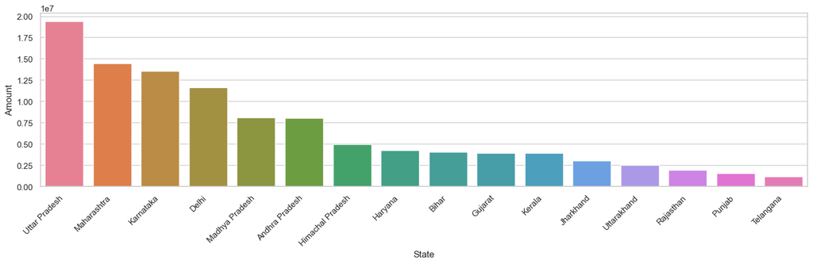

```python
sales_state=df.groupby(["State"],as_index=False)["Amount"].sum().sort_values(by="Amount",ascending=False)
sns.set(style="whitegrid")
plt.figure(figsize=(15,5))
sns.barplot(x="State",y="Amount",data=sales_state,hue="State")
plt.xticks(rotation=45,ha="right")
plt.tight_layout()
plt.show()
```

*we can conclude that Uttar pradesh purchasing rate is more and Telangana as least purchasing rate overall*

# Marital status

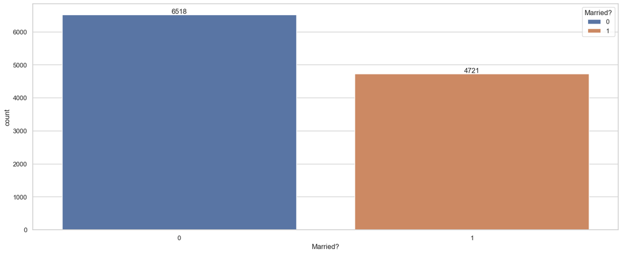

```python
ax=sns.countplot(x="Married?",data=df,hue="Married?")
for bar in ax.containers:
    ax.bar_label(bar)
```

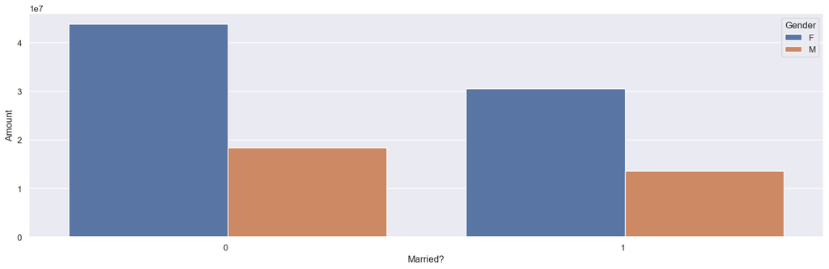

```python
sales_state=df.groupby(["Married?","Gender"],as_index=False)["Amount"].sum().sort_values(by="Amount",ascending=False)
plt.figure(figsize=(15,5))
sns.barplot(x="Married?",y="Amount",data=sales_state,hue="Gender")
plt.xticks(rotation=0,ha="right")
plt.tight_layout()
plt.show()
```

*In the above cell we can see that female who not married paid more than female who married and same thing for mens also

```python
df["Occupation"]
```

```
0             Healthcare
1                   Govt
2             Automobile
3           Construction
4        Food Processing
              ...
11246           Chemical
11247         Healthcare
11248            Textile
11249        Agriculture
11250         Healthcare
Name: Occupation, Length: 11239, dtype: str
```

[figure not shown]

```python
plt.figure(figsize=(15,5))
sales_Occupation=sns.countplot(x="Occupation",data=df,order=order,hue="Occupation")
plt.xticks(rotation=45,ha="right")
plt.tight_layout()
for bar in sales_Occupation.containers:
    sales_Occupation.bar_label(bar)
```

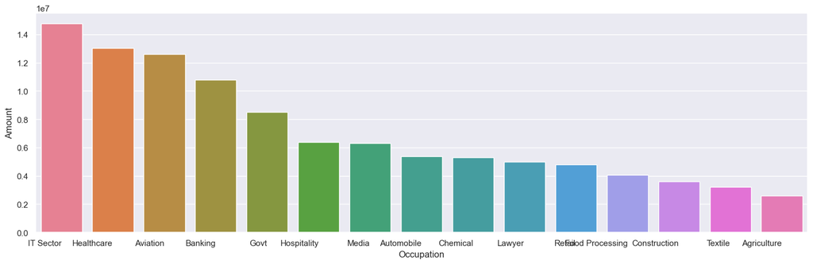

```python
sales_Occupation=df.groupby(["Occupation"],as_index=False)["Amount"].sum().sort_values(by="Amount",ascending=False)
plt.figure(figsize=(15,5))
sns.barplot(x="Occupation",y="Amount",data=sales_Occupation,hue="Occupation")
plt.xticks(rotation=0,ha="right")
plt.tight_layout()
plt.show()
```

*from the above cell we can say the people who are working in IT sector they paid more amount than others

# Product Category

```python
df["Product_Category"].value_counts()
```

```
Product_Category
Clothing & Apparel       2655
Food                     2490
Electronics & Gadgets    2087
Footwear & Shoes         1059
Household items           520
Beauty                    422
Games & Toys              386
Sports Products           356
Furniture                 352
Pet Care                  212
Office                    113
Stationery                112
Books                     103
Auto                       97
Decor                      96
Veterinary                 81
Tupperware                 72
Hand & Power Tools         26
Name: count, dtype: int64
```

```python
df.columns
```

```
Index(['User_ID', 'Cust_name', 'Product_ID', 'Gender', 'Age Group', 'Age',
       'Married?', 'State', 'Zone', 'Occupation', 'Product_Category', 'Orders',
       'Amount'],
      dtype='str')
```

```python
df['Product_Category']
```

```
0              Auto
1              Auto
2              Auto
3              Auto
4              Auto
            ...
11246        Office
11247    Veterinary
11248        Office
11249        Office
11250        Office
Name: Product_Category, Length: 11239, dtype: str
```

```python
df['Product_Category']
```

```
0              Auto
1              Auto
2              Auto
3              Auto
4              Auto
            ...
11246        Office
11247    Veterinary
11248        Office
11249        Office
11250        Office
Name: Product_Category, Length: 11239, dtype: str
```

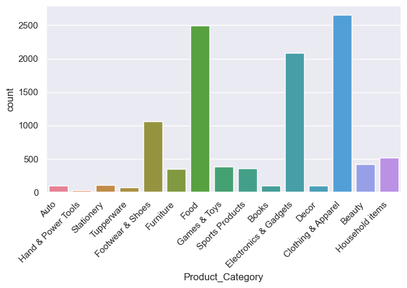

```python
first_10_category=df['Product_Category'].unique()[:15]
plt.figure(figsize=(7,5))
sns.countplot(x='Product_Category',data=df,order=first_10_category,hue='Product_Category')
plt.xticks(rotation=45, ha='right')
plt.tight_layout()
plt.show()
```

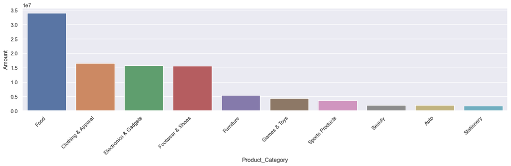

```python
sales_occupation=df.groupby(['Product_Category'],as_index=False)["Amount"].sum().sort_values(by="Amount",ascending=False).head(10)
plt.figure(figsize=(15,5))
sns.barplot(x='Product_Category',y="Amount",data=sales_occupation,hue='Product_Category')
plt.xticks(rotation=45,ha="right")
plt.tight_layout()
plt.show()
```

*from above graph we can tell that food category product as saled and reached highest than others*

```python
df["Product_ID"]
```

```
0        P00125942
1        P00110942
2        P00118542
3        P00237842
4        P00057942
           ...
11246    P00296942
11247    P00171342
11248    P00201342
11249    P00059442
11250    P00281742
Name: Product_ID, Length: 11239, dtype: str
```

# Product ID

```python
df["Product_ID"].value_counts()
```

```
Product_ID
P00265242    53
P00110942    44
P00184942    37
P00237542    35
P00112142    34
             ..
P00216242     1
P00121942     1
P00307142     1
P00044742     1
P00296942     1
Name: count, Length: 2350, dtype: int64
```

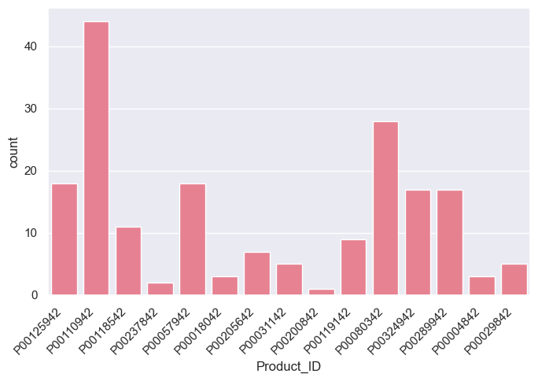

```python
first_10_category=df['Product_ID'].unique()[:15]
plt.figure(figsize=(7,5))
sns.countplot(x='Product_ID',data=df,order=first_10_category,hue='Product_ID')
plt.xticks(rotation=45, ha='right')
plt.tight_layout()
plt.show()
```

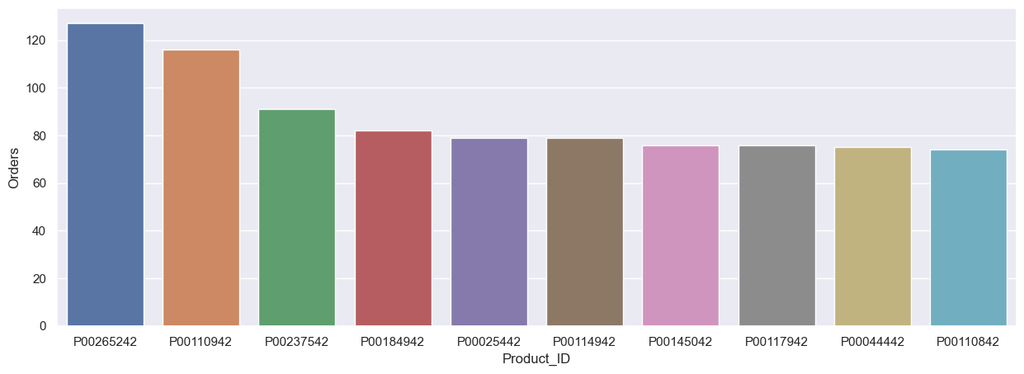

```python
sales_productid=df.groupby(['Product_ID'],as_index=False)["Orders"].sum().sort_values(by="Orders",ascending=False).head(10)
sns.set(rc={'figure.figsize':(15,5)})
sns.barplot(x='Product_ID',y="Orders",data=sales_productid,hue="Product_ID")
plt.show()
```

# Conclusion

**The whomen who is not married yet from uttar pradesh buying more product(Food) who from IT sector with most counter product id which is P00265242**

*Project Learnings

Performed data cleaning and manipulation

Performed exploratory data analysis (EDA) using pandas, matplotlib and seaborn libraries

Improved customer experience by identifying potential customers across different states, occupation, gender and age groups

Improved sales by identifying most selling product categories and products, which can help to plan inventory and hence meet the demands*

https://github.com/DARSHAN-B-2004